# COVID-19 modeling in South Dakota

May 28, 2020

# Authors

*Jeff Wesner, Ph.D.*<sup>1</sup>, *Dan Van Peursem, Ph.D.*<sup>2</sup>, *Jose Flores, Ph.D.*<sup>2,3</sup>, *Yuhlong Lio, Ph.D.*<sup>2</sup>

University of South Dakota

<sup>1</sup>Department of Biology, <sup>2</sup>Department of Mathematical Sciences, <sup>3</sup>Department of Computer Science

Jeff.Wesner@usd.edu

# Purpose

To predict hospital bed needs, ICU needs, and ventilator needs in South Dakota due to COVID-19.

# Alternative Approach

## Directly modeling hospital bed use

Our previous approach attempted to estimate hospital bed use from an initial SIR (https://github.com/jswesner/covid_sd/blob/master/code/alternative_analysis.pdf). However, there is now enough data to directly model the curve of cumulative COVID related hospitalizations. To do that, we first used the Weibull equation to fit a Bayesian non-linear curve to cumulative hospitalization data (first graph below). We then converted that cumulative prediction to active hospitalizations by varying the days in the hospital to fit the data on active hospitalizations.

[figure not shown]

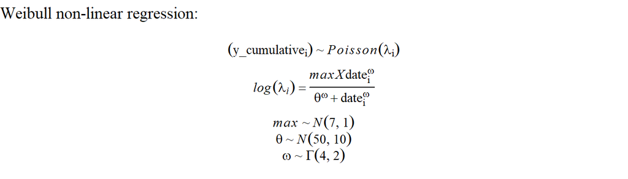

## Weibull results

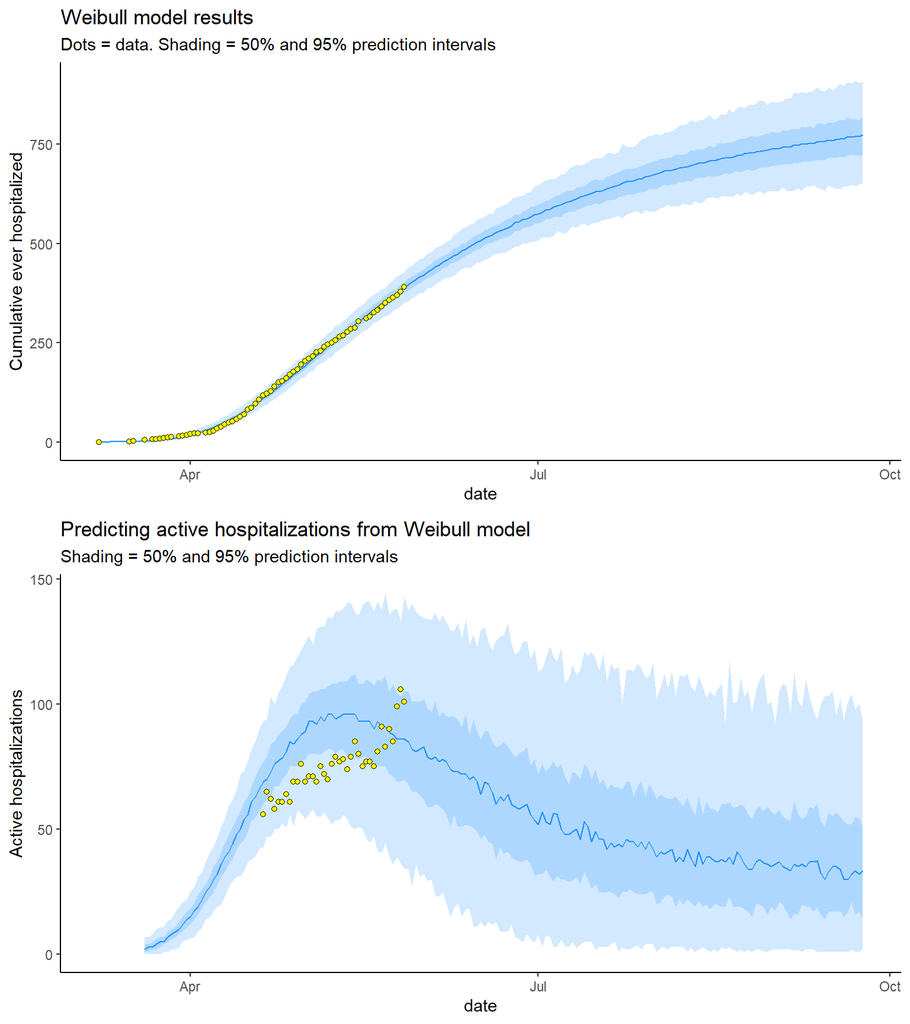

## Divergent trends outside of Minnehaha County

The above analysis makes predictions for the state of South Dakota, but most of the early cases in the state happened in Minnehaha County. As shown below, when we plot the hospitalization trends separately, Minnehaha County appears to have nearly peaked in cumulative hospitalizations while the rest of South Dakota is still in the exponential phase of growth. To capture this dynamic, we re-fit the model above but with separate random intercepts for each group (one for Minnehaha County and one for the rest of South Dakota).

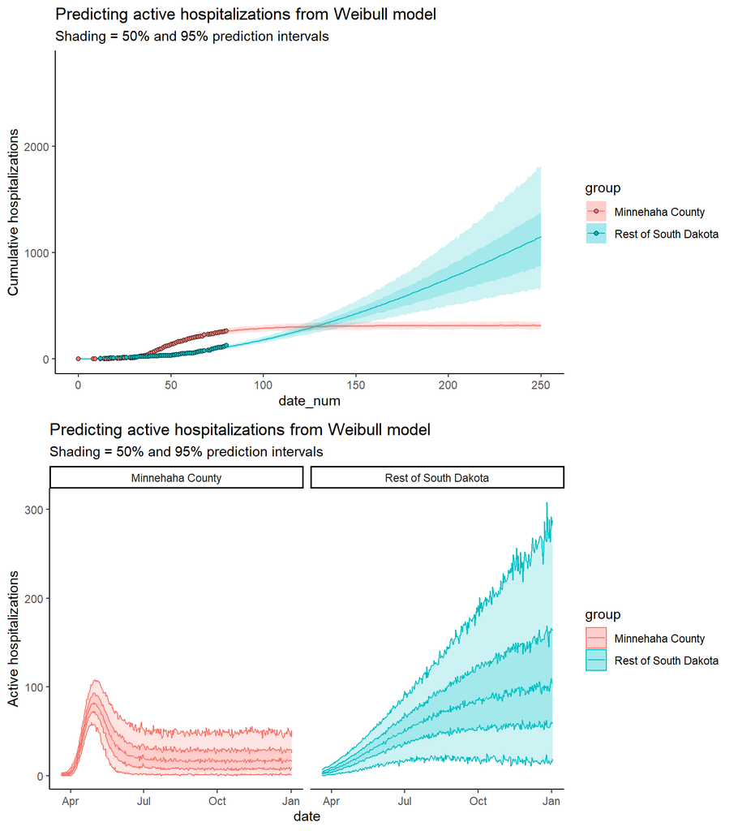

## Influence of the priors

The plot below compares the prior predictive distribution (i.e. running the model with only the prior information, not the data) to the posterior predictive distribution. The large difference in these predictions indicates that we learned a lot of information from the data and the priors have relatively small influences.

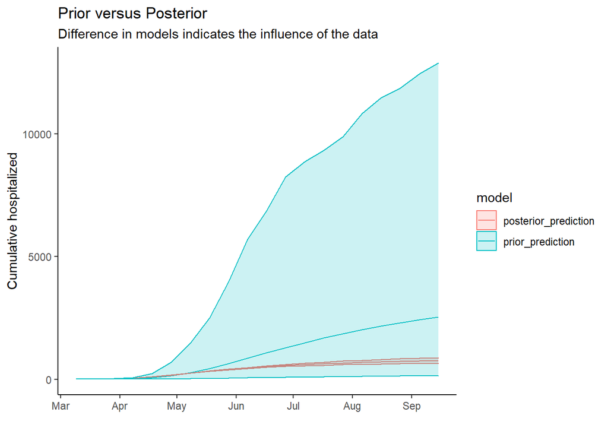